# 人工智能知識及應用證書（兼讀制）實習二

Date : 01-Oct-2021 v1.1

### Learning Objective

- This tutorial is to demonstrate how to build a more complicated Neural Network model in R
- Students may follow the instructions and gain hands-on experience buiding an AI model.
- This is a handwritten pattern recognition tutorial.
- By completing the tutorial, students should be able to solve real-world AI problems.

### Prerequisite

- Students should complete 人工智能知識及應用證書（兼讀制）實習一

```r
install.packages('neuralnet')
install.packages('dplyr')
install.packages("remotes")
remotes::install_github('stillmatic/MNIST')
```

Task 1: Install the R Packages

```r
library(neuralnet)
library(MNIST)
library(dplyr)
```

Task 2: Load the packages  
**Question** What is MNIST?  
**Question** What is dplyr?

```r
class(mnist_train)
```

```
[1] "data.frame"
```

```r
nrow(mnist_train)
```

```
[1] 60000
```

```r
ncol(mnist_train)
```

```
[1] 785
```

```r
head(colnames(mnist_train))
```

```
[1] "V1" "V2" "V3" "V4" "V5" "V6"
```

Task 3: Exam the raw data  
Execute the above. Note that the outcome variable is a factor, which can take on 10 values.  
**Question** Verify that there are 60000 observations, 785 variables, as 784 predictors and 1 outcome variable.

```r
showImage = function(data, row_index){
  #Obtaining the row as a numeric vector
  r = as.numeric(data[row_index, 1:784])

  #Creating a empty matrix to use
  im = matrix(nrow = 28, ncol = 28)

  #Filling properly the data into the matrix
  j = 1
  for(i in 28:1){
    im[,i] = r[j:(j+27)]
    j = j+28
  }

  #Plotting the image with the label
  image(x = 1:28,
      y = 1:28,
      z = im,
      col=gray((0:255)/255),
      main = paste("Number:", data[row_index, 'y']))
}
# REF : https://stackoverflow.com/questions/37953644/r-image-plot-mnist-dataset/49483988
```

Task 4: Define a function to show an image  
**Question** What is the size of the image?

```r
print(mnist_train[3, ])
```

|  | V1 | V2 | V3 | V4 | V5 | V6 | V7 | V8 | V9 | V10 | V11 | V12 | V13 | V14 | V15 | V16 | V17 | V18 | V19 | V20 | V21 | V22 | V23 | V24 | V25 | V26 | V27 | V28 | V29 | … |
| --- | --- | --- | --- | --- | --- | --- | --- | --- | --- | --- | --- | --- | --- | --- | --- | --- | --- | --- | --- | --- | --- | --- | --- | --- | --- | --- | --- | --- | --- | --- |
| 3 | 0 | 0 | 0 | 0 | 0 | 0 | 0 | 0 | 0 | 0 | 0 | 0 | 0 | 0 | 0 | 0 | 0 | 0 | 0 | 0 | 0 | 0 | 0 | 0 | 0 | 0 | 0 | 0 | 0 | … |

Task 5: Look at the raw data values  
**Question** What does the three in mnist_train[3, ] mean?  
**Question** What does the zero (the value of V1) mean?

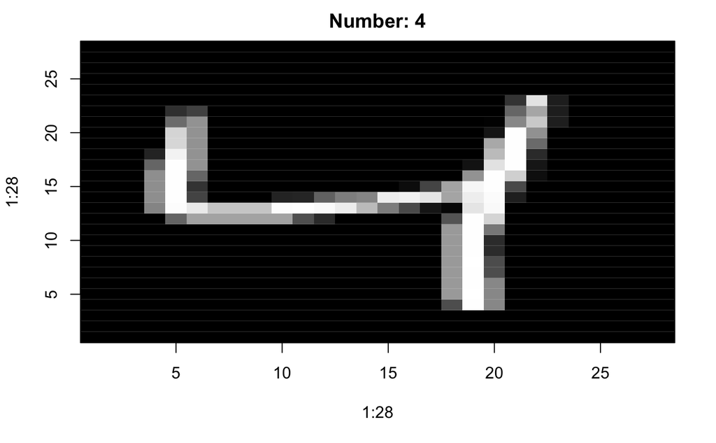

```r
showImage(mnist_train, row_index=3)
```

Task 6: Visulalize the data

```r
str(mnist_train[3,'V1'])
```

```
 int 0
```

```r
str(mnist_train[3,'y'])
```

```
 Factor w/ 10 levels "0","1","2","3",..: 5
```

Task 7: int vs Factor  
The factor setup is not supported by the neuralnet package, which operates in a matrix framework.

```r
inds <- nnet::class.ind(mnist_train$y)
inds %>% head
```

```
     0 1 2 3 4 5 6 7 8 9
[1,] 0 0 0 0 0 1 0 0 0 0
[2,] 1 0 0 0 0 0 0 0 0 0
[3,] 0 0 0 0 1 0 0 0 0 0
[4,] 0 1 0 0 0 0 0 0 0 0
[5,] 0 0 0 0 0 0 0 0 0 1
[6,] 0 0 1 0 0 0 0 0 0 0
```

```r
str(inds[3,])
```

```
 Named num [1:10] 0 0 0 0 1 0 0 0 0 0
 - attr(*, "names")= chr [1:10] "0" "1" "2" "3" ...
```

```r
# head(inds) if we do not use pipeline programming technique
```

Task 8: Preparation (Fixing Factor)

```r
colnames(inds) <- paste("val", colnames(inds), sep = "")
f <- as.formula(paste(paste(colnames(inds), collapse = "+"), " ~ ",
                      paste(names(MNIST::mnist_train)[1:784], collapse = "+")))
f
```

```
val0 + val1 + val2 + val3 + val4 + val5 + val6 + val7 + val8 +
    val9 ~ V1 + V2 + V3 + V4 + V5 + V6 + V7 + V8 + V9 + V10 +
    V11 + V12 + V13 + V14 + V15 + V16 + V17 + V18 + V19 + V20 +
    V21 + V22 + V23 + V24 + V25 + V26 + V27 + V28 + V29 + V30 +
    V31 + V32 + V33 + V34 + V35 + V36 + V37 + V38 + V39 + V40 +
    V41 + V42 + V43 + V44 + V45 + V46 + V47 + V48 + V49 + V50 +
    V51 + V52 + V53 + V54 + V55 + V56 + V57 + V58 + V59 + V60 +
    V61 + V62 + V63 + V64 + V65 + V66 + V67 + V68 + V69 + V70 +
    V71 + V72 + V73 + V74 + V75 + V76 + V77 + V78 + V79 + V80 +
    V81 + V82 + V83 + V84 + V85 + V86 + V87 + V88 + V89 + V90 +
    V91 + V92 + V93 + V94 + V95 + V96 + V97 + V98 + V99 + V100 +
    V101 + V102 + V103 + V104 + V105 + V106 + V107 + V108 + V109 +
    V110 + V111 + V112 + V113 + V114 + V115 + V116 + V117 + V118 +
    V119 + V120 + V121 + V122 + V123 + V124 + V125 + V126 + V127 +
    V128 + V129 + V130 + V131 + V132 + V133 + V134 + V135 + V136 +
    V137 + V138 + V139 + V140 + V141 + V142 + V143 + V144 + V145 +
    V146 + V147 + V148 + V149 + V150 + V151 + V152 + V153 + V154 +
    V155 + V156 + V157 + V158 + V159 + V160 + V161 + V162 + V163 +
    V164 + V165 + V166 + V167 + V168 + V169 + V170 + V171 + V172 +
    V173 + V174 + V175 + V176 + V177 + V178 + V179 + V180 + V181 +
    V182 + V183 + V184 + V185 + V186 + V187 + V188 + V189 + V190 +
    V191 + V192 + V193 + V194 + V195 + V196 + V197 + V198 + V199 +
    V200 + V201 + V202 + V203 + V204 + V205 + V206 + V207 + V208 +
    V209 + V210 + V211 + V212 + V213 + V214 + V215 + V216 + V217 +
    V218 + V219 + V220 + V221 + V222 + V223 + V224 + V225 + V226 +
    V227 + V228 + V229 + V230 + V231 + V232 + V233 + V234 + V235 +
    V236 + V237 + V238 + V239 + V240 + V241 + V242 + V243 + V244 +
    V245 + V246 + V247 + V248 + V249 + V250 + V251 + V252 + V253 +
    V254 + V255 + V256 + V257 + V258 + V259 + V260 + V261 + V262 +
    V263 + V264 + V265 + V266 + V267 + V268 + V269 + V270 + V271 +
    V272 + V273 + V274 + V275 + V276 + V277 + V278 + V279 + V280 +
    V281 + V282 + V283 + V284 + V285 + V286 + V287 + V288 + V289 +
    V290 + V291 + V292 + V293 + V294 + V295 + V296 + V297 + V298 +
    V299 + V300 + V301 + V302 + V303 + V304 + V305 + V306 + V307 +
    V308 + V309 + V310 + V311 + V312 + V313 + V314 + V315 + V316 +
    V317 + V318 + V319 + V320 + V321 + V322 + V323 + V324 + V325 +
    V326 + V327 + V328 + V329 + V330 + V331 + V332 + V333 + V334 +
    V335 + V336 + V337 + V338 + V339 + V340 + V341 + V342 + V343 +
    V344 + V345 + V346 + V347 + V348 + V349 + V350 + V351 + V352 +
    V353 + V354 + V355 + V356 + V357 + V358 + V359 + V360 + V361 +
```

[output cut: 32 more lines]

```
    V650 + V651 + V652 + V653 + V654 + V655 + V656 + V657 + V658 +
    V659 + V660 + V661 + V662 + V663 + V664 + V665 + V666 + V667 +
    V668 + V669 + V670 + V671 + V672 + V673 + V674 + V675 + V676 +
    V677 + V678 + V679 + V680 + V681 + V682 + V683 + V684 + V685 +
    V686 + V687 + V688 + V689 + V690 + V691 + V692 + V693 + V694 +
    V695 + V696 + V697 + V698 + V699 + V700 + V701 + V702 + V703 +
    V704 + V705 + V706 + V707 + V708 + V709 + V710 + V711 + V712 +
    V713 + V714 + V715 + V716 + V717 + V718 + V719 + V720 + V721 +
    V722 + V723 + V724 + V725 + V726 + V727 + V728 + V729 + V730 +
    V731 + V732 + V733 + V734 + V735 + V736 + V737 + V738 + V739 +
    V740 + V741 + V742 + V743 + V744 + V745 + V746 + V747 + V748 +
    V749 + V750 + V751 + V752 + V753 + V754 + V755 + V756 + V757 +
    V758 + V759 + V760 + V761 + V762 + V763 + V764 + V765 + V766 +
    V767 + V768 + V769 + V770 + V771 + V772 + V773 + V774 + V775 +
    V776 + V777 + V778 + V779 + V780 + V781 + V782 + V783 + V784
```

Task 9: Preparation

```r
indsdf=data.frame(inds)
trainData = cbind(mnist_train[, 1:784], indsdf)
trainData = trainData %>% sample_frac(0.01)
nrow(trainData)
```

```
[1] 600
```

```r
ncol(trainData)
```

```
[1] 794
```

Task 10: Training Data Preparation  
**Question** Explain the meaning of 600 by executing nrow(trainData)?  
**Question** Explain 794 above?

```r
colnames(trainData)
```

```
  [1] "V1"   "V2"   "V3"   "V4"   "V5"   "V6"   "V7"   "V8"   "V9"   "V10"  "V11"  "V12"  "V13"
 [14] "V14"  "V15"  "V16"  "V17"  "V18"  "V19"  "V20"  "V21"  "V22"  "V23"  "V24"  "V25"  "V26"
 [27] "V27"  "V28"  "V29"  "V30"  "V31"  "V32"  "V33"  "V34"  "V35"  "V36"  "V37"  "V38"  "V39"
 [40] "V40"  "V41"  "V42"  "V43"  "V44"  "V45"  "V46"  "V47"  "V48"  "V49"  "V50"  "V51"  "V52"
 [53] "V53"  "V54"  "V55"  "V56"  "V57"  "V58"  "V59"  "V60"  "V61"  "V62"  "V63"  "V64"  "V65"
 [66] "V66"  "V67"  "V68"  "V69"  "V70"  "V71"  "V72"  "V73"  "V74"  "V75"  "V76"  "V77"  "V78"
 [79] "V79"  "V80"  "V81"  "V82"  "V83"  "V84"  "V85"  "V86"  "V87"  "V88"  "V89"  "V90"  "V91"
 [92] "V92"  "V93"  "V94"  "V95"  "V96"  "V97"  "V98"  "V99"  "V100" "V101" "V102" "V103" "V104"
[105] "V105" "V106" "V107" "V108" "V109" "V110" "V111" "V112" "V113" "V114" "V115" "V116" "V117"
[118] "V118" "V119" "V120" "V121" "V122" "V123" "V124" "V125" "V126" "V127" "V128" "V129" "V130"
[131] "V131" "V132" "V133" "V134" "V135" "V136" "V137" "V138" "V139" "V140" "V141" "V142" "V143"
[144] "V144" "V145" "V146" "V147" "V148" "V149" "V150" "V151" "V152" "V153" "V154" "V155" "V156"
[157] "V157" "V158" "V159" "V160" "V161" "V162" "V163" "V164" "V165" "V166" "V167" "V168" "V169"
[170] "V170" "V171" "V172" "V173" "V174" "V175" "V176" "V177" "V178" "V179" "V180" "V181" "V182"
[183] "V183" "V184" "V185" "V186" "V187" "V188" "V189" "V190" "V191" "V192" "V193" "V194" "V195"
```

[output cut: 47 more lines]

Task 11: Check the column names

```r
model = neuralnet::neuralnet(f, data = trainData,
                           hidden = 3, linear.output = F)
```

Task 12: Model  
**Question** What is f?  
**Question** How trainData is related to f?  
**Question** What is hidden?  
**Question** Why linear.output is FALSE?

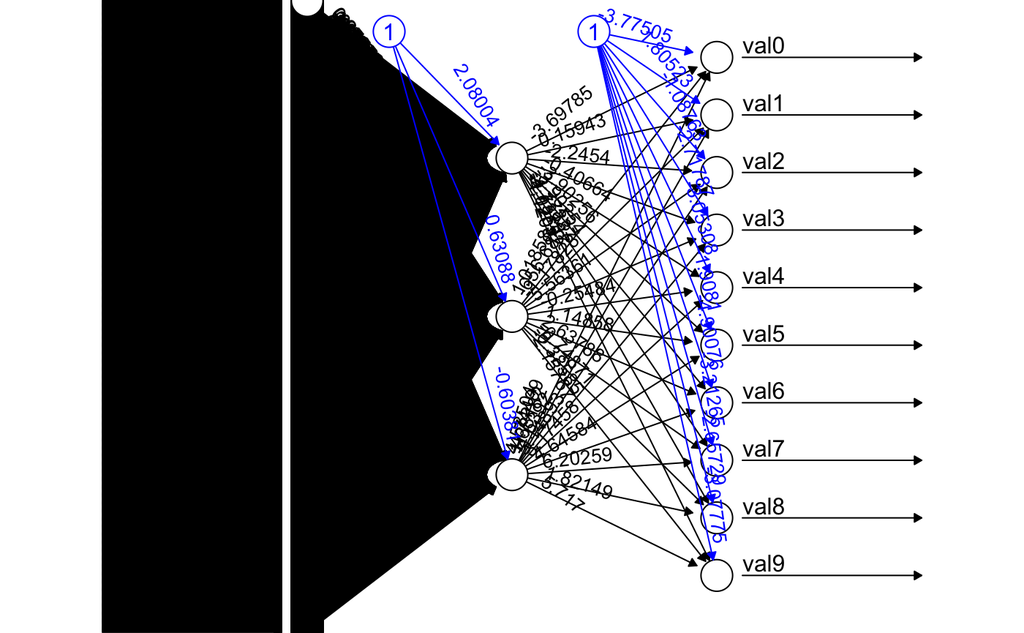

```r
plot(model)
```

Task 13: Plot Model  
Execute head(model$result.matrix) to obtain the error  
**Question** How could we decrease the neural network error?

```r
preds <- neuralnet::compute(model, mnist_test[1, 1:784])
print(mnist_test[1, 'y'])
```

```
[1] 7
Levels: 0 1 2 3 4 5 6 7 8 9
```

```r
preds$net.result
```

```
        [,1]      [,2]      [,3]        [,4]     [,5]       [,6]       [,7]      [,8]      [,9]
1 0.05275703 0.0583963 0.1609461 0.000424701 0.141036 0.06685375 0.01740765 0.1491307 0.1344328
      [,10]
1 0.1851935
```

Task 14: Classify unknown character  
**Question** What is the predicted number?  
**Question** Verify the result by calling showImage?

### Exercises

[1] CRM  
Explain how to classify valuable customers from the sales database. Note that each company may keep different data sets. Students should make some assumptions.

[2] Smart ERP  
Explain how to neural networks could be adopted to solve inventory replenishment problem.  
Hints: predict the stock movement.

[3] COVID19

```r
install.packages("COVID19")
library("COVID19")
usdat=covid19(c("USA"), level = 2)
usDF=data.frame(na.omit(usdat[ , c( 'confirmed', 'recovered', 'deaths')]))
head(usDF)
```

**Question** Explain the R code above  
**Question** If confirmed=5555 and deaths=333, what could be ‘recovered’?

### Reference

[1] MNIST Package  
https://rdrr.io/github/stillmatic/MNIST/f/vignettes/neuralnet-mnist.Rmd